# Pokemon Stat Analysis

Bailey Joseph

11/28/2017

```r
library(readr)
library(dplyr)
```

```r
library(ggplot2)
library(stringr)
```

```r
pokemon <- read_csv("../data/pokemon.csv")
pokemon$`Type 1` <- as.factor(pokemon$`Type 1`)
pokemon$`Type 2` <- as.factor(pokemon$`Type 2`)
pokemon$Legendary <- as.factor(pokemon$Legendary)
pokemon$atk_spread <- abs(pokemon$Attack - pokemon$`Sp. Atk`)
```

```r
gen1 <- filter(pokemon, Generation == 1)
gen2 <- filter(pokemon, Generation == 2)
gen3 <- filter(pokemon, Generation == 3)
gen4 <- filter(pokemon, Generation == 4)
gen5 <- filter(pokemon, Generation == 5)
gen6 <- filter(pokemon, Generation == 6 |
                 (str_detect(pokemon$Name, "Mega") &
                    !str_detect(pokemon$Name, "Meganium")))

gen1 <- gen1[!str_detect(gen1$Name, "Mega"), ]
gen2 <- gen2[!str_detect(gen2$Name, "Mega") | str_detect(gen2$Name, "Meganium"), ]
gen3 <- gen3[!str_detect(gen3$Name, "Mega"), ]
gen4 <- gen4[!str_detect(gen4$Name, "Mega"), ]
gen5 <- gen5[!str_detect(gen5$Name, "Mega"), ]
```

```r
ave_stats_by_gen <- rep(0, 6)
ave_stats_by_gen[1] <- mean(gen1$Total)
ave_stats_by_gen[2] <- mean(gen2$Total)
ave_stats_by_gen[3] <- mean(gen3$Total)
ave_stats_by_gen[4] <- mean(gen4$Total)
ave_stats_by_gen[5] <- mean(gen5$Total)
ave_stats_by_gen[6] <- mean(gen6$Total)
num_mons_by_gen <- rep(0, 6)
num_mons_by_gen[1] <- nrow(gen1)
num_mons_by_gen[2] <- nrow(gen2)
num_mons_by_gen[3] <- nrow(gen3)
num_mons_by_gen[4] <- nrow(gen4)
num_mons_by_gen[5] <- nrow(gen5)
num_mons_by_gen[6] <- nrow(gen6)
ave_stats_by_gen
```

```
## [1] 407.0795 406.1800 411.5571 451.9310 434.3171 501.7442
```

```r
num_mons_by_gen
```

```
## [1] 151 100 140 116 164 129
```

```r
by_gen <- data.frame("generation" = 1:6,
                     "ave_stats" = ave_stats_by_gen,
                     "num_mons" = num_mons_by_gen)
by_gen
```

```
##   generation ave_stats num_mons
## 1          1  407.0795      151
## 2          2  406.1800      100
## 3          3  411.5571      140
## 4          4  451.9310      116
## 5          5  434.3171      164
## 6          6  501.7442      129
```

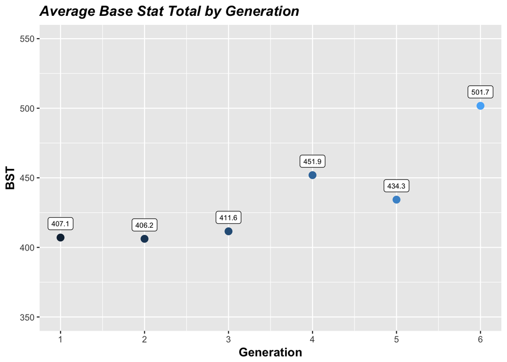

```r
average_total_by_generation <- (ggplot(data = by_gen,
                                       aes(x = generation,
                                           y = ave_stats)) +
                                 geom_point(size = 3,
                                            aes(color = generation)) +
                                  ylim(c(350,550)) +
                                  scale_x_continuous(breaks = 1:6) +
                                  labs(title = "Average Base Stat Total by Generation",
                                       x = "Generation",
                                       y = "BST") +
                                  geom_label(aes(label = round(ave_stats, 1)),
                            alpha = 1,
                             # nudge_x = .25,
                             nudge_y = 10,
                              size = 2.5) +
                                  theme(plot.title = element_text(color = "black",
                                                    size = 14,
                                                    face = "bold.italic"),
                                       axis.title.x = element_text(size = 12,
                                                  face = "bold"),
                                       axis.title.y = element_text(size = 12,
                                                      face = "bold"),
                                       legend.position = "none"))
average_total_by_generation
```

What about percentage of Pokemon that are strong? Define strong as base 500 or higher. Examples of pokemon with exactly 500 BST are Alakazam, Gengar, Scizor, and Rapidash (you can see that some of these are more competitively viable than others, so take the word “strong” with a grain of salt).

```r
count(pokemon, Total >= 500)$n[2]/nrow(pokemon)
```

```
## [1] 0.30875
```

For reference, about 30% of pokemon have a BST of 500 or more.

```r
frac_strong_by_gen <- rep(0, 6)
frac_strong_by_gen[1] <- count(gen1, Total >= 500)$n[2]/nrow(gen1)
frac_strong_by_gen[2] <- count(gen2, Total >= 500)$n[2]/nrow(gen2)
frac_strong_by_gen[3] <- count(gen3, Total >= 500)$n[2]/nrow(gen3)
frac_strong_by_gen[4] <- count(gen4, Total >= 500)$n[2]/nrow(gen4)
frac_strong_by_gen[5] <- count(gen5, Total >= 500)$n[2]/nrow(gen5)
frac_strong_by_gen[6] <- count(gen6, Total >= 500)$n[2]/nrow(gen6)
by_gen$frac_strong <- round(frac_strong_by_gen, 2)
by_gen
```

```
##   generation ave_stats num_mons frac_strong
## 1          1  407.0795      151        0.22
## 2          2  406.1800      100        0.25
## 3          3  411.5571      140        0.20
## 4          4  451.9310      116        0.41
## 5          5  434.3171      164        0.26
## 6          6  501.7442      129        0.54
```

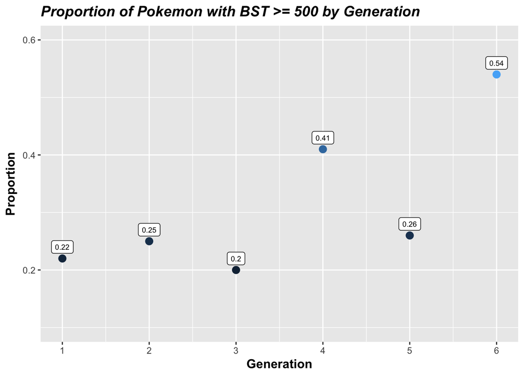

```r
frac_strong_by_generation <- (ggplot(data = by_gen,
                                       aes(x = generation,
                                           y = frac_strong)) +
                                 geom_point(size = 3,
                                            aes(color = frac_strong)) +
                                  ylim(c(.1,.6)) +
                                  scale_x_continuous(breaks = 1:6) +
                                  labs(title = "Proportion of Pokemon with BST >= 500 by Generation",
                                       x = "Generation",
                                       y = "Proportion") +
                                  geom_label(aes(label = frac_strong),
                            alpha = 1,
                             # nudge_x = .25,
                             nudge_y = .02,
                              size = 2.5) +
                                  theme(plot.title = element_text(color = "black",
                                                    size = 14,
                                                    face = "bold.italic"),
                                       axis.title.x = element_text(size = 12,
                                                  face = "bold"),
                                       axis.title.y = element_text(size = 12,
                                                      face = "bold"),
                                       legend.position = "none"))
frac_strong_by_generation
```

It’s also possible that there’s a more sneaky form of power creep going on. A pokemon usually only needs one of its attack stats to function. Even with the same base stat total, a pokemon with 125 attack and 25 special attack will be much stronger than a pokemon with 75 in both stats. Let’s measure how much the spread between different attack stats changes over time.

```r
ave_spread_by_gen <- rep(0, 6)
ave_spread_by_gen[1] <- mean(gen1$atk_spread)
ave_spread_by_gen[2] <- mean(gen2$atk_spread)
ave_spread_by_gen[3] <- mean(gen3$atk_spread)
ave_spread_by_gen[4] <- mean(gen4$atk_spread)
ave_spread_by_gen[5] <- mean(gen5$atk_spread)
ave_spread_by_gen[6] <- mean(gen6$atk_spread)
by_gen$ave_spread <- round(ave_spread_by_gen, 1)
```

```r
cor(by_gen$generation, by_gen$ave_spread)
```

```
## [1] 0.6007632
```

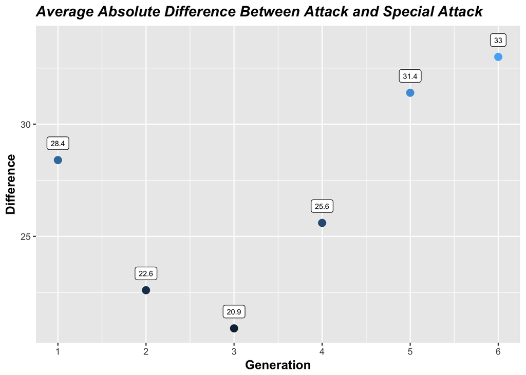

```r
ave_spread_by_generation <- (ggplot(data = by_gen,
                                       aes(x = generation,
                                           y = ave_spread)) +
                                 geom_point(size = 3,
                                            aes(color = ave_spread)) +
                                 # ylim(c(.1,.6)) +
                                  scale_x_continuous(breaks = 1:6) +
                                  labs(title = "Average Absolute Difference Between Attack and Special Attack",
                                       x = "Generation",
                                       y = "Difference") +
                                  geom_label(aes(label = ave_spread),
                            alpha = 1,
                             # nudge_x = .25,
                             nudge_y = .75,
                              size = 2.5) +
                                  theme(plot.title = element_text(color = "black",
                                                    size = 14,
                                                    face = "bold.italic"),
                                       axis.title.x = element_text(size = 12,
                                                  face = "bold"),
                                       axis.title.y = element_text(size = 12,
                                                      face = "bold"),
                                       legend.position = "none"))
ave_spread_by_generation
```